# Developing an AI application

Going forward, AI algorithms will be incorporated into more and more everyday applications. For example, you might want to include an image classifier in a smart phone app. To do this, you'd use a deep learning model trained on hundreds of thousands of images as part of the overall application architecture. A large part of software development in the future will be using these types of models as common parts of applications.

In this project, you'll train an image classifier to recognize different species of flowers. You can imagine using something like this in a phone app that tells you the name of the flower your camera is looking at. In practice you'd train this classifier, then export it for use in your application. We'll be using [this dataset](http://www.robots.ox.ac.uk/~vgg/data/flowers/102/index.html) of 102 flower categories, you can see a few examples below.

[figure not shown]

The project is broken down into multiple steps:

- Load and preprocess the image dataset
- Train the image classifier on your dataset
- Use the trained classifier to predict image content

We'll lead you through each part which you'll implement in Python.

When you've completed this project, you'll have an application that can be trained on any set of labeled images. Here your network will be learning about flowers and end up as a command line application. But, what you do with your new skills depends on your imagination and effort in building a dataset. For example, imagine an app where you take a picture of a car, it tells you what the make and model is, then looks up information about it. Go build your own dataset and make something new.

First up is importing the packages you'll need. It's good practice to keep all the imports at the beginning of your code. As you work through this notebook and find you need to import a package, make sure to add the import up here.

```python
# Ensures plotting functions are displayed in a format suitable to the chosen frontend
%matplotlib inline
%config InlineBackend.figure_format = 'retina'

# Standard Imports here
import time
import json
import copy

# Standard functionality and visualisation packages/modules
import numpy as np
import pandas as pd
import matplotlib.pyplot as plt
import seaborn as sb
import cv2

# Pytorch/ Deep Learning specific packages/modules
import torchvision
import torch
from torch import nn #Neural Network modules
from torch import optim #Gradient Descent modules
import torch.nn.functional as F # Additional functions if necessary
from torch.optim import lr_scheduler
from torch.autograd import Variable
from torchvision import datasets, transforms, models # Importing core structures / frameworks
from collections import OrderedDict
from PIL import Image
```

## Load the data

Here you'll use `torchvision` to load the data ([documentation](http://pytorch.org/docs/0.3.0/torchvision/index.html)). The data should be included alongside this notebook, otherwise you can [download it here](https://s3.amazonaws.com/content.udacity-data.com/nd089/flower_data.tar.gz). The dataset is split into three parts, training, validation, and testing. For the training, you'll want to apply transformations such as random scaling, cropping, and flipping. This will help the network generalize leading to better performance. You'll also need to make sure the input data is resized to 224x224 pixels as required by the pre-trained networks.

The validation and testing sets are used to measure the model's performance on data it hasn't seen yet. For this you don't want any scaling or rotation transformations, but you'll need to resize then crop the images to the appropriate size.

The pre-trained networks you'll use were trained on the ImageNet dataset where each color channel was normalized separately. For all three sets you'll need to normalize the means and standard deviations of the images to what the network expects. For the means, it's `[0.485, 0.456, 0.406]` and for the standard deviations `[0.229, 0.224, 0.225]`, calculated from the ImageNet images. These values will shift each color channel to be centered at 0 and range from -1 to 1.

```python
#Defining the file paths for each folder set of images in the local directory
data_dir = 'flowers'
train_dir = data_dir + '/train' #flowers/train
valid_dir = data_dir + '/valid' #flowers/valid
test_dir = data_dir + '/test' #flowers/test
```

```python
# TODO: Define your transforms for the training, validation, and testing sets
# Transforms here serve 4 main purposes
# 1. Standardisation for the training and testing pipelines as constructed further on
# 2. Lossless transforms provide a large set of data for model training and testing
# 3. Numerous image orientations allow the model to better generalise to new images
# 4. We must fit the image orientation requirements to take advantage of the transfer learning model selected

# Specified Training set transforms:

data_transforms = {
    'train': transforms.Compose([ # Notation is used to compose several transforms together using the 'train' keyword
        transforms.RandomRotation(30), #Rotations
        transforms.RandomResizedCrop(224), #Resized cropping
        transforms.RandomVerticalFlip(), # Flipping
        transforms.ToTensor(), # Tensor format
        transforms.Normalize([0.485, 0.456, 0.406],
                             [0.229, 0.224, 0.225]) # Normalising colour channel
    ]),
    'valid': transforms.Compose([ # Notation is used to compose several transforms together using the 'val' keyword
        transforms.Resize(256), # Resizing image in line with transfer learning model requirements
        transforms.CenterCrop(224), # Cropping image in line with transfer learning model requirements
        transforms.ToTensor(), # Tensor format
        transforms.Normalize([0.485, 0.456, 0.406],
                             [0.229, 0.224, 0.225]) # Normalising colour channel
    ]),
    'test': transforms.Compose([ # Notation is used to compose several transforms together using the 'test' keyword
        transforms.Resize(256), # Resizing image in line with transfer learning model requirements
        transforms.CenterCrop(224), # Cropping image in line with transfer learning model requirements
        transforms.ToTensor(), # Tensor format
        transforms.Normalize([0.485, 0.456, 0.406],
                             [0.229, 0.224, 0.225]) # Normalising colour channel
    ]),
}


# TODO: Load the datasets with ImageFolder
# Using the ImageFolder function here we load the image datasets with their corresponding transforms

# May not need this as parent folder name is already given above
#train_dir = 'train'
#valid_dir = 'valid'
#test_dir  = 'test'

dirs = {'train': train_dir,
        'valid': valid_dir,
        'test' : test_dir}

image_datasets = {x: datasets.ImageFolder(dirs[x],   transform=data_transforms[x]) for x in ['train', 'valid', 'test']}

# TODO: Using the image datasets and the trainforms, define the dataloaders
# The dataloaders are functions used to load our transformed image datasets in batches for computational effeciency
# There are a couple of hyper parameters available here that can be trained to optimise loading/training/testing time
# Shuffling here simulates generalisation for the model and reduces potential bias

dataloaders = {x: torch.utils.data.DataLoader(image_datasets[x], batch_size=32, shuffle=True) for x in ['train', 'valid', 'test']}

dataset_sizes = {x: len(image_datasets[x]) for x in ['train', 'valid']}
```

### Label mapping

You'll also need to load in a mapping from category label to category name. You can find this in the file `cat_to_name.json`. It's a JSON object which you can read in with the [`json` module](https://docs.python.org/2/library/json.html). This will give you a dictionary mapping the integer encoded categories to the actual names of the flowers.

```python
# Mappings useful for classification and visualisation of image labels throughout the modelling process
import json

with open('cat_to_name.json', 'r') as f:
    flower_to_name = json.load(f)

print(len(flower_to_name))
print(flower_to_name)
```

```
102
{'21': 'fire lily', '3': 'canterbury bells', '45': 'bolero deep blue', '1': 'pink primrose', '34': 'mexican aster', '27': 'prince of wales feathers', '7': 'moon orchid', '16': 'globe-flower', '25': 'grape hyacinth', '26': 'corn poppy', '79': 'toad lily', '39': 'siam tulip', '24': 'red ginger', '67':…
```

# Building and training the classifier

Now that the data is ready, it's time to build and train the classifier. As usual, you should use one of the pretrained models from `torchvision.models` to get the image features. Build and train a new feed-forward classifier using those features.

We're going to leave this part up to you. Refer to [the rubric](https://review.udacity.com/#!/rubrics/1663/view) for guidance on successfully completing this section. Things you'll need to do:

- Load a [pre-trained network](http://pytorch.org/docs/master/torchvision/models.html) (If you need a starting point, the VGG networks work great and are straightforward to use)
- Define a new, untrained feed-forward network as a classifier, using ReLU activations and dropout
- Train the classifier layers using backpropagation using the pre-trained network to get the features
- Track the loss and accuracy on the validation set to determine the best hyperparameters

We've left a cell open for you below, but use as many as you need. Our advice is to break the problem up into smaller parts you can run separately. Check that each part is doing what you expect, then move on to the next. You'll likely find that as you work through each part, you'll need to go back and modify your previous code. This is totally normal!

When training make sure you're updating only the weights of the feed-forward network. You should be able to get the validation accuracy above 70% if you build everything right. Make sure to try different hyperparameters (learning rate, units in the classifier, epochs, etc) to find the best model. Save those hyperparameters to use as default values in the next part of the project.

One last important tip if you're using the workspace to run your code: To avoid having your workspace disconnect during the long-running tasks in this notebook, please read in the earlier page in this lesson called Intro to GPU Workspaces about Keeping Your Session Active. You'll want to include code from the workspace_utils.py module.

**Note for Workspace users:** If your network is over 1 GB when saved as a checkpoint, there might be issues with saving backups in your workspace. Typically this happens with wide dense layers after the convolutional layers. If your saved checkpoint is larger than 1 GB (you can open a terminal and check with `ls -lh`), you should reduce the size of your hidden layers and train again.

```python
# Use Transfer Learning to make use of pre-trained models available through the PyTorch framework
# First off we want to check the architecture of the pretrained model to see does it suit our modelling objective

model = models.vgg16(pretrained=True) #Using VGG16 as reccomended
model # Printing model to view architecture used, how features are selected and how classifier is constructed

# We can see from the output layer of the algorithm that the pretrained model is designed to predict 1000 classes
# We only require 102 classes so will need to reconfigure this accordingly
# We also need to ensure that the number of input features is in line with the first input layer: 25088
```

```
VGG(
  (features): Sequential(
    (0): Conv2d(3, 64, kernel_size=(3, 3), stride=(1, 1), padding=(1, 1))
    (1): ReLU(inplace)
    (2): Conv2d(64, 64, kernel_size=(3, 3), stride=(1, 1), padding=(1, 1))
    (3): ReLU(inplace)
    (4): MaxPool2d(kernel_size=2, stride=2, padding=0, dilation=1, ceil_mode=False)
    (5): Conv2d(64, 128, kernel_size=(3, 3), stride=(1, 1), padding=(1, 1))
    (6): ReLU(inplace)
    (7): Conv2d(128, 128, kernel_size=(3, 3), stride=(1, 1), padding=(1, 1))
    (8): ReLU(inplace)
    (9): MaxPool2d(kernel_size=2, stride=2, padding=0, dilation=1, ceil_mode=False)
    (10): Conv2d(128, 256, kernel_size=(3, 3), stride=(1, 1), padding=(1, 1))
    (11): ReLU(inplace)
    (12): Conv2d(256, 256, kernel_size=(3, 3), stride=(1, 1), padding=(1, 1))
    (13): ReLU(inplace)
    (14): Conv2d(256, 256, kernel_size=(3, 3), stride=(1, 1), padding=(1, 1))
    (15): ReLU(inplace)
    (16): MaxPool2d(kernel_size=2, stride=2, padding=0, dilation=1, ceil_mode=False)
    (17): Conv2d(256, 512, kernel_size=(3, 3), stride=(1, 1), padding=(1, 1))
    (18): ReLU(inplace)
    (19): Conv2d(512, 512, kernel_size=(3, 3), stride=(1, 1), padding=(1, 1))
    (20): ReLU(inplace)
    (21): Conv2d(512, 512, kernel_size=(3, 3), stride=(1, 1), padding=(1, 1))
    (22): ReLU(inplace)
    (23): MaxPool2d(kernel_size=2, stride=2, padding=0, dilation=1, ceil_mode=False)
    (24): Conv2d(512, 512, kernel_size=(3, 3), stride=(1, 1), padding=(1, 1))
    (25): ReLU(inplace)
    (26): Conv2d(512, 512, kernel_size=(3, 3), stride=(1, 1), padding=(1, 1))
    (27): ReLU(inplace)
    (28): Conv2d(512, 512, kernel_size=(3, 3), stride=(1, 1), padding=(1, 1))
    (29): ReLU(inplace)
    (30): MaxPool2d(kernel_size=2, stride=2, padding=0, dilation=1, ceil_mode=False)
  )
  (classifier): Sequential(
    (0): Linear(in_features=25088, out_features=4096, bias=True)
    (1): ReLU(inplace)
    (2): Dropout(p=0.5)
    (3): Linear(in_features=4096, out_features=4096, bias=True)
    (4): ReLU(inplace)
    (5): Dropout(p=0.5)
    (6): Linear(in_features=4096, out_features=1000, bias=True)
  )
)
```

```python
# Freeze pretrained model parameters to avoid backpropogating through them
# This ensures we don’t update the weights from the pre-trained model.

for parameter in model.parameters():
    parameter.requires_grad = False

# We want to ensure the final layers are consistent with our problem by using an ordered dictionary.
classifier = nn.Sequential(OrderedDict([('fc1', nn.Linear(25088, 5000)), # Number of neurons is a hyperparameter
                                        ('relu', nn.ReLU()), # ReLU activation function will squish the output space of the previous layer
                                        ('drop', nn.Dropout(p=0.5)), # Used to prevent overfitting - for any node in the network this will equate to 50% chance it will be randomly turned off
                                        ('fc2', nn.Linear(5000, 102)), # Input 5000, Output layer of 102
                                        ('output', nn.LogSoftmax(dim=1))])) # Squishes the output space to be between 0 - 1 i.e. probability of class assignment for each image. Ideal for multiclass problems

# Ensure we overwrite the model classifier with the newly configured ordered dictionary
model.classifier = classifier
```

```python
# Next we can build our model pipeline in a functional manner

def train_model(model, criteria, optimizer, scheduler,
                                      num_epochs=25, device='cuda'):
    since = time.time()
    model.cuda() # ensure model is moved to GPU space along with tensors

    best_model_wts = copy.deepcopy(model.state_dict())
    best_acc = 0.0

    for epoch in range(num_epochs):
        print('Epoch {}/{}'.format(epoch, num_epochs - 1))
        print('-' * 10)

        # Each epoch has a training and validation phase
        for phase in ['train', 'valid']:
            if phase == 'train':
                scheduler.step()
                model.train()  # Set model to training mode
            else:
                model.eval()   # Set model to evaluate mode

            running_loss = 0.0
            running_corrects = 0

            # Iterate over data.
            for inputs, labels in dataloaders[phase]:
                inputs = inputs.to(device)
                labels = labels.to(device)

                # zero the parameter gradients
                optimizer.zero_grad()

                # forward
                # track history if only in train
                with torch.set_grad_enabled(phase == 'train'):
                    outputs = model(inputs)
                    _, preds = torch.max(outputs, 1)
                    loss = criterion(outputs, labels)

                    # backward + optimize only if in training phase
                    if phase == 'train':
                        loss.backward()
                        optimizer.step()

                # statistics
                running_loss += loss.item() * inputs.size(0)
                running_corrects += torch.sum(preds == labels.data)

            epoch_loss = running_loss / dataset_sizes[phase]
            epoch_acc = running_corrects.double() / dataset_sizes[phase]

            print('{} Loss: {:.4f} Acc: {:.4f}'.format(
                phase, epoch_loss, epoch_acc))

            # deep copy the model
            if phase == 'valid' and epoch_acc > best_acc:
                best_acc = epoch_acc
                best_model_wts = copy.deepcopy(model.state_dict())

        print()

    time_elapsed = time.time() - since
    print('Training complete in {:.0f}m {:.0f}s'.format(
        time_elapsed // 60, time_elapsed % 60))
    print('Best val Acc: {:4f}'.format(best_acc))

    # load best model weights
    model.load_state_dict(best_model_wts)
    return model
```

```python
# Setting up the model input arguments (hyperparameters)

# Model, criterion, optimizer, scheduler, num_epochs=25, device='cuda'

# Model is initialised in block above to pretrained vgg16 with classifier adjusted

# Criteria here represents the loss function used to evaluate the model fit
# NLLLoss which is recommended with Softmax final layer
criterion = nn.NLLLoss()

# Observe that all parameters are being optimized with a learning rate of 0.001 for gradient descent
optim = torch.optim.Adam(model.classifier.parameters(), lr=0.001)

# Provides different methods for adjusting the learning rate and step size used during optimisation
# Uses a scheduled Stepwise Decay of the LR by a factor of 0.1 every 3 epochs
sched = lr_scheduler.StepLR(optim, step_size=3, gamma=0.1)

# Number of epochs is the number of full run of feedforward and backpropagation through the network.
eps=12

# We want to ensure we use the GPU space available by selecting device as cuda
```

```python
# Finally we can call our training function supplying each of the defined arguments
model_ft = train_model(model, criterion, optim, sched, eps, 'cuda')
```

[output not shown]

## Testing your network

It's good practice to test your trained network on test data, images the network has never seen either in training or validation. This will give you a good estimate for the model's performance on completely new images. Run the test images through the network and measure the accuracy, the same way you did validation. You should be able to reach around 70% accuracy on the test set if the model has been trained well.

```python
# TODO: Do validation on the test set

def test_acc(model, data, cuda=False):
    model.eval() # Notify model layers we are in evaluation mode and not training mode
    model.to(device='cuda') # Send to GPU for faster processing

    with torch.no_grad(): #Speed up computations and save memory by not back propogating as we are in evaluation mode.
        for idx, (inputs, labels) in enumerate(dataloaders[data]):
            if cuda:
                inputs, labels = inputs.cuda(), labels.cuda()
            # obtain the outputs from the model
            outputs = model.forward(inputs)
            # max provides the (maximum probability, max value)
            _, predicted = outputs.max(dim=1)
            # check the
            if idx == 0:
                print(predicted) #the predicted class
                print(torch.exp(_)) # the predicted probability
            equals = predicted == labels.data
            if idx == 0:
                print(equals)
            print(equals.float().mean())
```

```python
test_acc(model, 'test', True)
```

```
tensor([  90,  101,    4,   81,  101,   78,   24,   98,   31,   88,
          73,   66,   68,    1,   96,    8,   18,   75,   92,   83,
          82,   74,   72,   45,   90,   78,   83,   53,   18,   85,
          31,   59], device='cuda:0')
tensor([ 0.2164,  1.0000,  1.0000,  0.8292,  0.8969,  0.9258,  1.0000,
         0.6682,  0.9946,  0.9482,  0.9875,  0.9665,  0.9481,  0.9962,
         1.0000,  0.4967,  1.0000,  0.7362,  0.9604,  0.7678,  0.9916,
         0.9964,  0.7661,  0.9454,  0.9910,  0.9596,  0.3168,  0.2449,
         1.0000,  0.4017,  0.9984,  0.9056], device='cuda:0')
tensor([ 0,  1,  1,  1,  1,  1,  1,  1,  1,  1,  1,  1,  1,  1,
         1,  1,  1,  0,  1,  1,  1,  1,  1,  0,  1,  1,  0,  0,
         1,  0,  1,  1], dtype=torch.uint8, device='cuda:0')
tensor(0.8125, device='cuda:0')
tensor(0.8125, device='cuda:0')
tensor(0.9062, device='cuda:0')
tensor(0.9062, device='cuda:0')
tensor(0.8750, device='cuda:0')
tensor(0.7812, device='cuda:0')
tensor(0.7188, device='cuda:0')
tensor(0.9062, device='cuda:0')
tensor(0.8438, device='cuda:0')
tensor(0.8750, device='cuda:0')
tensor(0.8125, device='cuda:0')
tensor(0.8438, device='cuda:0')
tensor(0.8750, device='cuda:0')
tensor(0.8438, device='cuda:0')
tensor(0.8125, device='cuda:0')
tensor(0.8438, device='cuda:0')
tensor(0.8125, device='cuda:0')
tensor(0.9062, device='cuda:0')
tensor(0.9062, device='cuda:0')
tensor(0.9375, device='cuda:0')
tensor(0.7188, device='cuda:0')
tensor(0.8438, device='cuda:0')
tensor(0.8750, device='cuda:0')
tensor(0.9375, device='cuda:0')
tensor(0.8750, device='cuda:0')
tensor(0.7895, device='cuda:0')
```

## Save the checkpoint

Now that your network is trained, save the model so you can load it later for making predictions. You probably want to save other things such as the mapping of classes to indices which you get from one of the image datasets: `image_datasets['train'].class_to_idx`. You can attach this to the model as an attribute which makes inference easier later on.

`model.class_to_idx = image_datasets['train'].class_to_idx`

Remember that you'll want to completely rebuild the model later so you can use it for inference. Make sure to include any information you need in the checkpoint. If you want to load the model and keep training, you'll want to save the number of epochs as well as the optimizer state, `optimizer.state_dict`. You'll likely want to use this trained model in the next part of the project, so best to save it now.

```python
# TODO: Save the checkpoint using the following functions

print("Our model: \n\n", model, '\n')
print("The state dict keys: \n\n", model.state_dict().keys())

def save_checkpoint(model):

    model.class_to_idx = image_datasets['train'].class_to_idx
    model.cpu()
    checkpoint = {'arch': "vgg16", # Key for the architecture chosen - in this case vgg16
                  'class_to_idx': model.class_to_idx, # This holds the flower image label mappings to compare against our predictions
                  'model_state_dict': model.state_dict(), # Holds all of the weights and biases of our model for each layer
                  'optimizer': optimizer.state_dict, # Holds the optimiser class chosen in place
                  'input_size': (3, 224, 224), # Image input criteria
                  'output_size': 102, # Number of output classes in final layer
                  'batch_size': 32, # Batch size for loading images
                  'epochs': 12 # Number of epochs used
                 }
    torch.save(checkpoint, 'checkpoint.pth') # This takes a dictionary of model configuration and a path as a destination

save_checkpoint(model) # Run the function to save our model
```

## Loading the checkpoint

At this point it's good to write a function that can load a checkpoint and rebuild the model. That way you can come back to this project and keep working on it without having to retrain the network.

```python
# TODO: Write a function that loads a checkpoint and rebuilds the model

def get_checkpoint(checkpoint_path):
    chpt = torch.load(checkpoint_path)

    #Checking to see if architecture of model is the same as trained model
    if chpt['arch'] == 'vgg16':
        model = models.vgg16(pretrained=True)
        for param in model.parameters(): #Freezing the model parameters
            param.requires_grad = False

    else:
        print("Sorry base architecture note recognized") #Try-catch


    model.class_to_idx = chpt['class_to_idx'] #Applying checkpoint to model class to index mapping

    # Create the classifier
    classifier = nn.Sequential(OrderedDict([('fc1', nn.Linear(25088, 5000)), # Number of neurons is a hyperparameter
                                        ('relu', nn.ReLU()), # ReLU activation function will squish the output space of the previous layer
                                        ('drop', nn.Dropout(p=0.5)), # Used to prevent overfitting - for any node in the network this will equate to 50% chance it will be randomly turned off
                                        ('fc2', nn.Linear(5000, 102)), # Input 5000, Output layer of 102
                                        ('output', nn.LogSoftmax(dim=1))])) # Squishes the output space to be between 0 - 1 i.e. probability of class assignment for each image. Ideal for multiclass problems

    # Put the classifier on the pretrained network
    model.classifier = classifier

    model.load_state_dict(chpt['model_state_dict'])

    return model
```

```python
# Testing Loading Success
load_model = get_checkpoint('checkpoint.pth')
print(load_model)
test_acc(load_model, 'test', True)
```

```
VGG(
  (features): Sequential(
    (0): Conv2d(3, 64, kernel_size=(3, 3), stride=(1, 1), padding=(1, 1))
    (1): ReLU(inplace)
    (2): Conv2d(64, 64, kernel_size=(3, 3), stride=(1, 1), padding=(1, 1))
    (3): ReLU(inplace)
    (4): MaxPool2d(kernel_size=2, stride=2, padding=0, dilation=1, ceil_mode=False)
    (5): Conv2d(64, 128, kernel_size=(3, 3), stride=(1, 1), padding=(1, 1))
    (6): ReLU(inplace)
    (7): Conv2d(128, 128, kernel_size=(3, 3), stride=(1, 1), padding=(1, 1))
    (8): ReLU(inplace)
    (9): MaxPool2d(kernel_size=2, stride=2, padding=0, dilation=1, ceil_mode=False)
    (10): Conv2d(128, 256, kernel_size=(3, 3), stride=(1, 1), padding=(1, 1))
    (11): ReLU(inplace)
    (12): Conv2d(256, 256, kernel_size=(3, 3), stride=(1, 1), padding=(1, 1))
    (13): ReLU(inplace)
    (14): Conv2d(256, 256, kernel_size=(3, 3), stride=(1, 1), padding=(1, 1))
    (15): ReLU(inplace)
    (16): MaxPool2d(kernel_size=2, stride=2, padding=0, dilation=1, ceil_mode=False)
    (17): Conv2d(256, 512, kernel_size=(3, 3), stride=(1, 1), padding=(1, 1))
    (18): ReLU(inplace)
    (19): Conv2d(512, 512, kernel_size=(3, 3), stride=(1, 1), padding=(1, 1))
    (20): ReLU(inplace)
    (21): Conv2d(512, 512, kernel_size=(3, 3), stride=(1, 1), padding=(1, 1))
    (22): ReLU(inplace)
    (23): MaxPool2d(kernel_size=2, stride=2, padding=0, dilation=1, ceil_mode=False)
    (24): Conv2d(512, 512, kernel_size=(3, 3), stride=(1, 1), padding=(1, 1))
    (25): ReLU(inplace)
    (26): Conv2d(512, 512, kernel_size=(3, 3), stride=(1, 1), padding=(1, 1))
    (27): ReLU(inplace)
    (28): Conv2d(512, 512, kernel_size=(3, 3), stride=(1, 1), padding=(1, 1))
    (29): ReLU(inplace)
    (30): MaxPool2d(kernel_size=2, stride=2, padding=0, dilation=1, ceil_mode=False)
  )
  (classifier): Sequential(
    (fc1): Linear(in_features=25088, out_features=5000, bias=True)
    (relu): ReLU()
    (drop): Dropout(p=0.5)
    (fc2): Linear(in_features=5000, out_features=102, bias=True)
    (output): LogSoftmax()
```

[output cut: 25 more lines]

```
tensor(0.8125, device='cuda:0')
tensor(0.7500, device='cuda:0')
tensor(0.8125, device='cuda:0')
tensor(0.9062, device='cuda:0')
tensor(0.9062, device='cuda:0')
tensor(0.7188, device='cuda:0')
tensor(0.8438, device='cuda:0')
tensor(0.8750, device='cuda:0')
tensor(0.8125, device='cuda:0')
tensor(0.7812, device='cuda:0')
tensor(0.9375, device='cuda:0')
tensor(0.8438, device='cuda:0')
tensor(0.8125, device='cuda:0')
tensor(0.8750, device='cuda:0')
tensor(0.8947, device='cuda:0')
```

# Inference for classification

Now you'll write a function to use a trained network for inference. That is, you'll pass an image into the network and predict the class of the flower in the image. Write a function called `predict` that takes an image and a model, then returns the top $K$ most likely classes along with the probabilities. It should look like

```
probs, classes = predict(image_path, model)
print(probs)
print(classes)
> [ 0.01558163  0.01541934  0.01452626  0.01443549  0.01407339]
> ['70', '3', '45', '62', '55']
```

First you'll need to handle processing the input image such that it can be used in your network.

## Image Preprocessing

You'll want to use `PIL` to load the image ([documentation](https://pillow.readthedocs.io/en/latest/reference/Image.html)). It's best to write a function that preprocesses the image so it can be used as input for the model. This function should process the images in the same manner used for training.

First, resize the images where the shortest side is 256 pixels, keeping the aspect ratio. This can be done with the [`thumbnail`](http://pillow.readthedocs.io/en/3.1.x/reference/Image.html#PIL.Image.Image.thumbnail) or [`resize`](http://pillow.readthedocs.io/en/3.1.x/reference/Image.html#PIL.Image.Image.thumbnail) methods. Then you'll need to crop out the center 224x224 portion of the image.

Color channels of images are typically encoded as integers 0-255, but the model expected floats 0-1. You'll need to convert the values. It's easiest with a Numpy array, which you can get from a PIL image like so `np_image = np.array(pil_image)`.

As before, the network expects the images to be normalized in a specific way. For the means, it's `[0.485, 0.456, 0.406]` and for the standard deviations `[0.229, 0.224, 0.225]`. You'll want to subtract the means from each color channel, then divide by the standard deviation.

And finally, PyTorch expects the color channel to be the first dimension but it's the third dimension in the PIL image and Numpy array. You can reorder dimensions using [`ndarray.transpose`](https://docs.scipy.org/doc/numpy-1.13.0/reference/generated/numpy.ndarray.transpose.html). The color channel needs to be first and retain the order of the other two dimensions.

```python
def process_image(image_path):
    ''' Scales, crops, and normalizes a PIL image for a PyTorch model,
        returns an Numpy array
    '''

    # TODO: Process a PIL image for use in a PyTorch model

    pil_image = Image.open(image_path)

    # Resize / Scale
    if pil_image.size[0] > pil_image.size[1]:
        pil_image.thumbnail((10000, 256))
    else:
        pil_image.thumbnail((256, 10000))

    # Crop Image
    left_margin = (pil_image.width-224)/2
    bottom_margin = (pil_image.height-224)/2
    right_margin = left_margin + 224
    top_margin = bottom_margin + 224

    pil_image = pil_image.crop((left_margin, bottom_margin, right_margin,
                      top_margin))

    # Normalize
    np_image = np.array(pil_image)/255
    mean = np.array([0.485, 0.456, 0.406])
    std = np.array([0.229, 0.224, 0.225])
    np_image = (np_image - mean) / std

    # Move color channels to first dimension as expected by PyTorch
    np_image = np_image.transpose((2, 0, 1))

    return np_image
```

To check your work, the function below converts a PyTorch tensor and displays it in the notebook. If your `process_image` function works, running the output through this function should return the original image (except for the cropped out portions).

```python
def imshow(image, ax=None, title=None):
    """Imshow for Tensor."""
    if ax is None:
        fig, ax = plt.subplots()

    # PyTorch tensors assume the color channel is the first dimension
    # but matplotlib assumes is the third dimension
    image = image.transpose((1, 2, 0))

    # Undo preprocessing
    mean = np.array([0.485, 0.456, 0.406])
    std = np.array([0.229, 0.224, 0.225])
    image = std * image + mean

    # Image needs to be clipped between 0 and 1 or it looks like noise when displayed
    image = np.clip(image, 0, 1)

    if title is not None:
        ax.set_title(title)

    ax.imshow(image)

    return ax
```

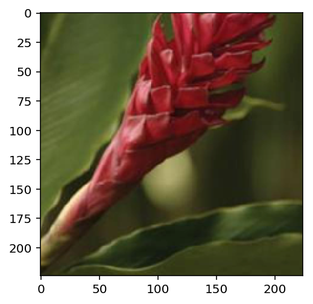

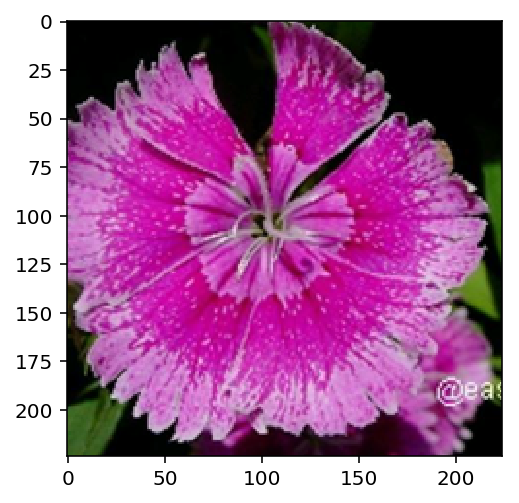

```python
# Testing the process_image function and result in plot form imshow - Should be same size and fit required dimensions
image = process_image('flowers/test/24/image_06815.jpg')
imshow(image)
imshow(process_image('flowers/test/30/image_03466.jpg'))
```